# Data science workflow

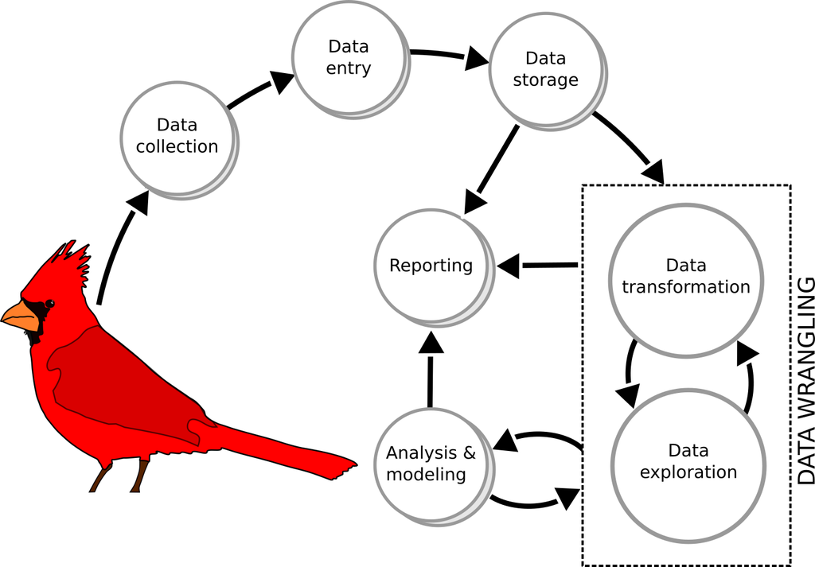

# Data science workflow

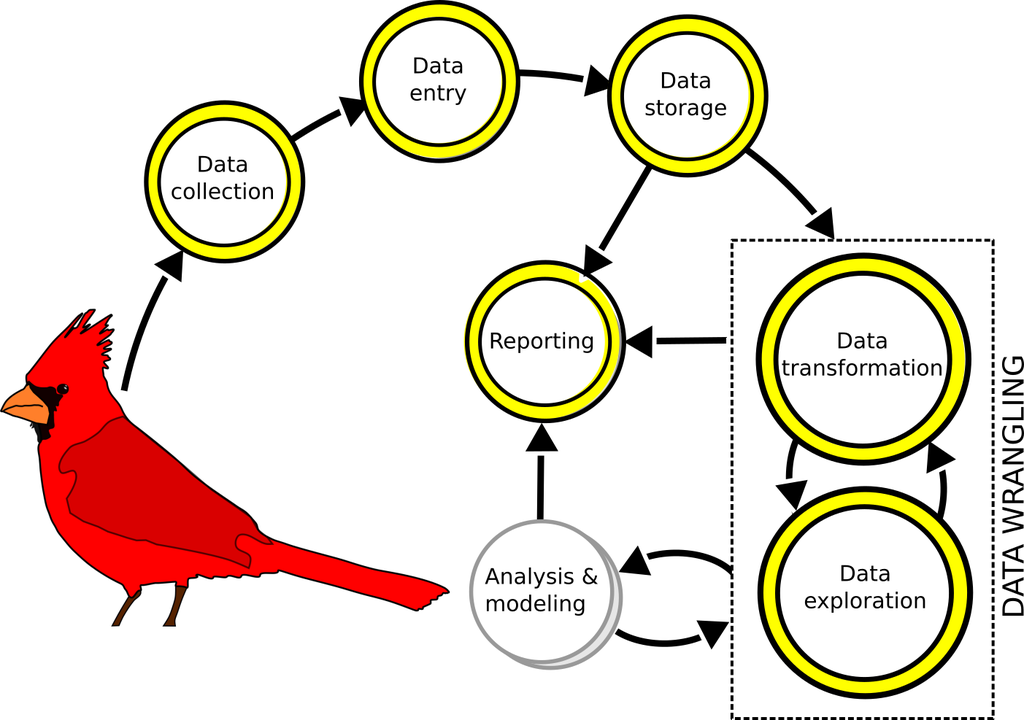

# Data science workflow

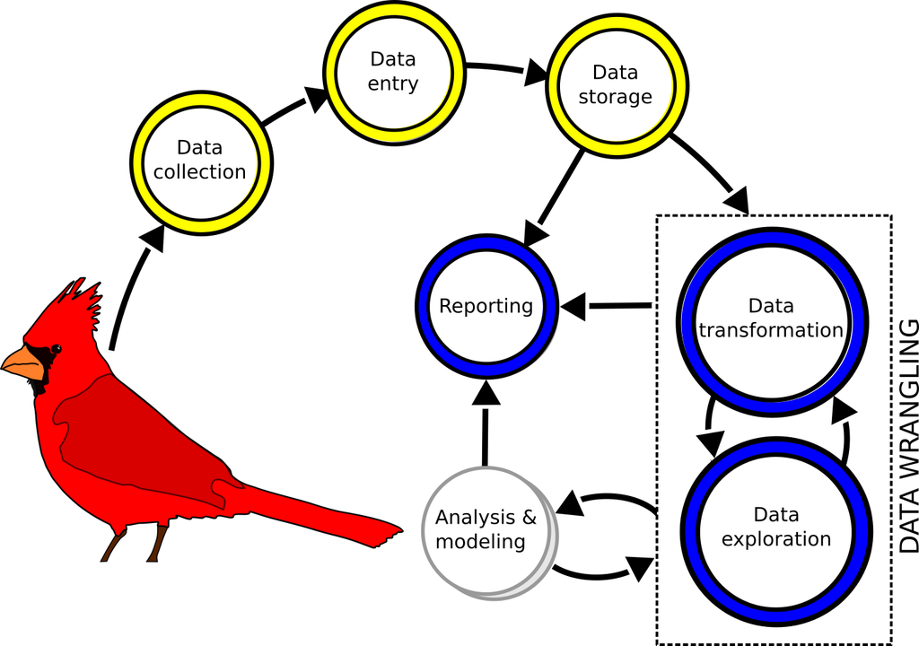

# Re-thinking data

How we’ve interacted with data dictates how we structure data mentally.

[figure not shown]

# Re-thinking data

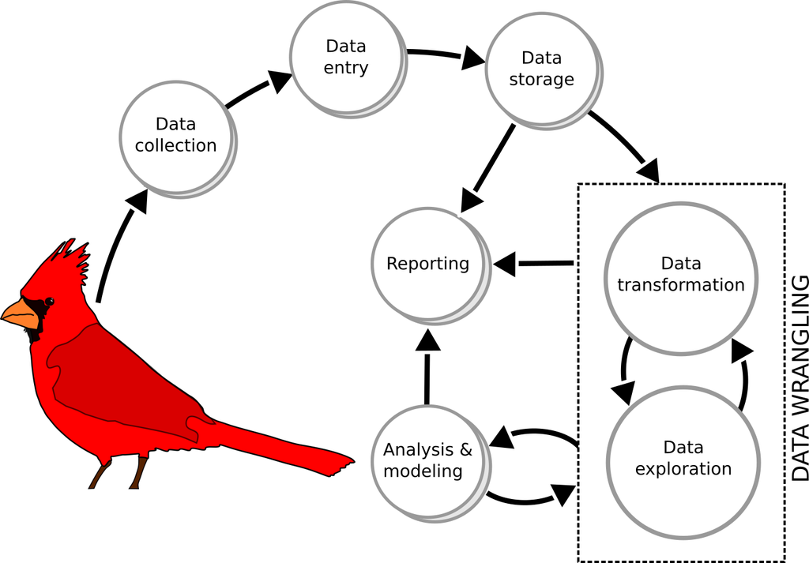

# Today’s goals

- **Value**: Any datum (single unit of data)
- **Object**: Container for holding values
- **Indexing**: Querying objects by position
- **Logic**: Querying objects using logical operators

# Values

A value is defined by its:

[figure not shown]

- State
- Attributes (metadata), e.g.:
  - Name
  - Class
- Context

# Values

Values are distinguished by similarities and differences in their multi-dimensional **states**, **attributes**, and **contexts**.

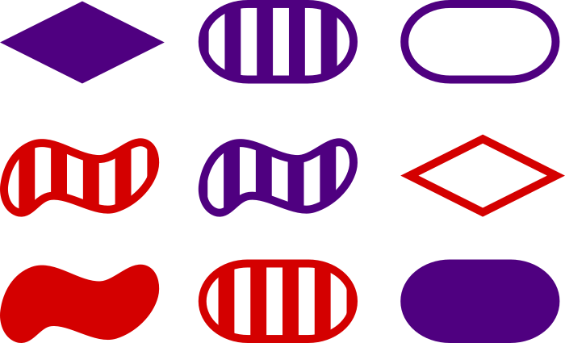

# Values

Values are distinguished by similarities and differences in their multi-dimensional **states**, **attributes**, and **contexts**.

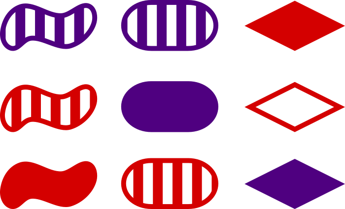

# Values

Values are distinguished by similarities and differences in their multi-dimensional **states**, **attributes**, and **contexts**.

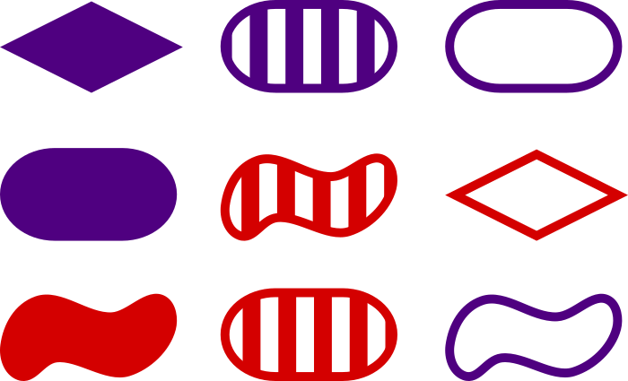

# Classes of values

In R, the most commonly used types of values are:

- **Number values**: numeric and integers
- **Character**: string (i.e., symbols)
- **Factor**: a smart combination of words/letters and integers
- **Logical**: integer values of 0 and 1 assigned to words

# Classes of values: Numeric

Number values can be either:

- **Numeric**: double precision floating point numbers (on the user end this can be thought of as a decimal number)
- **Integer**: whole numbers

```r
# Create a vector of numeric values:

numericV <- c(3, 2, 1, 1)

numericV
```

# Classes of values: Numbers

Number values can be either:

- **Numeric**: double precision floating point numbers (on the user end this can be thought of as a decimal number)
- **Integer**: whole numbers

```r
# What type of object is this?

class(numericV)

str(numericV)

summary(numericV)
```

# Classes of values: Numbers

Number values can be either:

- **Numeric**: double precision floating point numbers (on the user end this can be thought of as a decimal number)
- **Integer**: whole numbers

```r
# Create a vector of numeric integer values:

numericInteger <- 1:5

numericInteger

# What type of object is this?

class(numericInteger)

str(numericInteger)

summary(numericInteger)
```

# Classes of values: Character

A **character** or “string” value is a symbol or set of symbols from a given library

```r
# Create a vector of character values:

exampleCharacter <- c('three', 'two', 'one', 'one')

exampleCharacter

# What type of object is this?

class(exampleCharacter)

str(exampleCharacter)

summary(exampleCharacter)
```

# Classes of values: Factor

A **factor** value includes the following information:

- **Integer value**: Numeric integer value associated with factor level
- **Levels**: Character values associated with integer value
- **Labels**: Characters to assign to each factor level

```r
# Create a vector of factor values:

exampleFactor <- factor(c('three', 'two', 'one', 'one'))

exampleFactor

# What type of object is this?

class(exampleFactor)

str(exampleFactor)

summary(exampleFactor)
```

# Classes of values: Factor

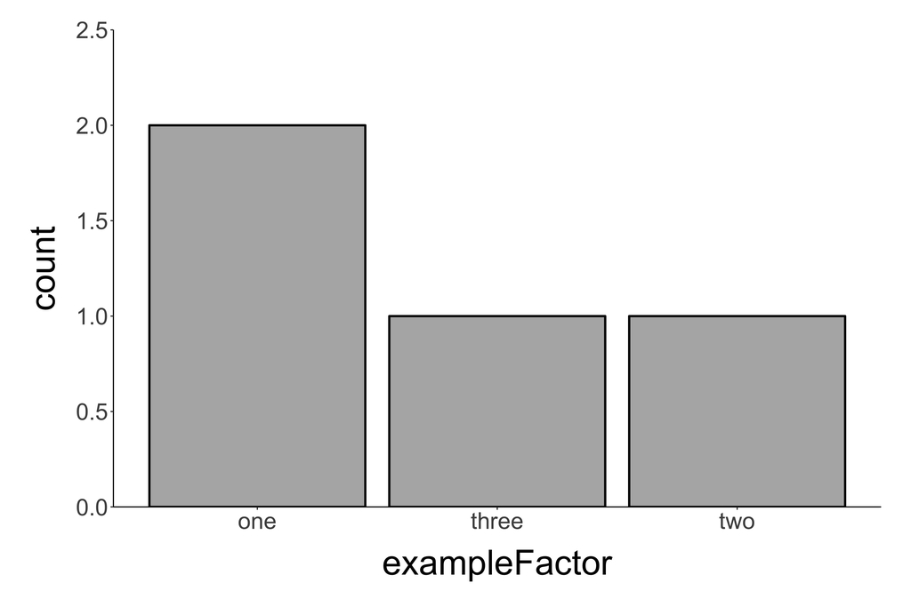

# Classes of values: Factor

A **factor** value includes the following information:

- **Integer value**: Numeric integer value associated with factor level
- **Levels**: Character values associated with integer value
- **Labels**: Characters to assign to each factor level

```r
# Set factor levels and labels:

factor(c('three', 'two', 'one', 'one'))

factor(
  c('three', 'two', 'one', 'one'),
  levels = c('one', 'two', 'three')
  )
```

# Classes of values: Factor

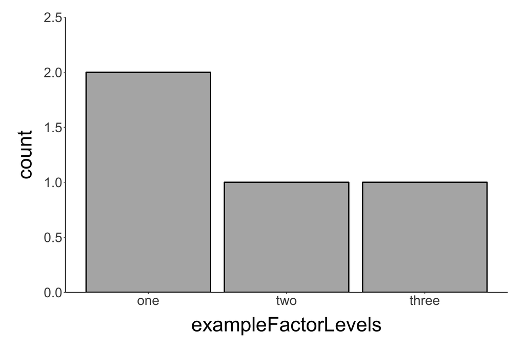

# Classes of values: Factor

A **factor** value includes the following information:

- **Integer value**: Numeric integer value associated with factor level
- **Levels**: Character values associated with integer value
- **Labels**: Characters to assign to each factor level

```r
# Set factor levels and labels:

factor(c('three', 'two', 'one', 'one'))

factor(
  c('three', 'two', 'one', 'one'),
  levels = c('one', 'two', 'three'),
  labels = c('One', 'Two', 'Three')
  )
```

# Classes of values: Factor

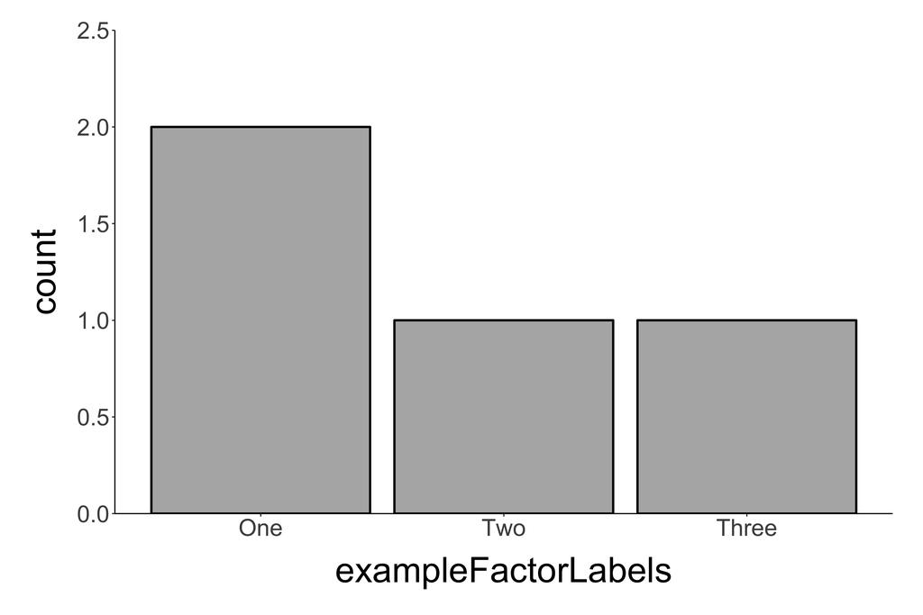

# Classes of values: Logical

R reserves the words TRUE and FALSE as logical constants. These constants are mapped to integer values:

- **FALSE**: 0
- **TRUE**: 1

```r
# Observe the behavior of logical values:

FALSE

TRUE

as.numeric(FALSE)

as.numeric(TRUE)

FALSE + TRUE

FALSE + TRUE + TRUE
```

# Classes of values: Logical

Logical values can be obtained by evaluating objects with **logical operators**. For example, the logical operator `==` tests whether a value is equal to another value.

```r
# The "is equal to" logical operator:

3 == 3

3 == 4

3 == 2 + 1

3 == 3 + 1

(3 == 3) + (3 == 2 + 1)
```

# Objects: Containers for values

In R, containers called **objects** structure collections of values. Different types of objects store values in different ways:

| Object dimensions | Homogeneous class | Heterogeneous class |
| --- | --- | --- |
| 1-D | Atomic vector | List |
| 2-D | Matrix | Data frame |

# Objects: Containers for values

For each object type, we’ll address:

- Structure
- Indexing
- Attributes

# Vector objects: Structure

An **atomic vector** is a one-dimensional collection of values. All values must be of the same class.

Each value in a vector has a position, denoted by “[*x*]”

| [1] | [2] | [3] | [4] |
| --- | --- | --- | --- |
| 1 | 1 | 2 | 3 |

# Vector objects: Structure

An **atomic vector** is a one-dimensional collection of values. All values must be of the same class.

```r
# A vector of numeric values:

numericVector <- c(1, 1, 2, 3)

numericVector
```

```
## [1] 1 1 2 3
```

```r
summary(numericVector)
```

```
##    Min. 1st Qu.  Median    Mean 3rd Qu.    Max.
##    1.00    1.00    1.50    1.75    2.25    3.00
```

# Vector objects: Structure

An **atomic vector** is a one-dimensional collection of values. All values must be of the same class.

```r
# All values in a vector must be of the same class:

numericVector
```

```
## [1] 1 1 2 3
```

```r
messyVector <- c(1, 'one', 2, 3)

messyVector
```

```
## [1] "1"   "one" "2"   "3"
```

# Vector objects: Indexing

Each value in a vector has a position, denoted by “[*x*]”

| [1] | [2] | [3] | [4] |
| --- | --- | --- | --- |
| 1 | 1 | 2 | 3 |

```r
# Use indexing to subset a vector:

numericVector

numericVector[3]

numericVector[3:4]

numericVector[c(1,3)]
```

# Vector objects: Attributes

Typical attributes we are interested in of vectors include:

- **Class**: What type of values?
- **Length**: How many values?

```r
# Attributes of the vector:

class(numericVector)

length(numericVector)

str(numericVector)
```

# Vector objects: Attributes

Attributes can be added to vectors.

```r
# Adding attributes to a vector:

numericVector

names(numericVector)

names(numericVector) <- c('orange', 'pear', 'apple', 'apple')
```

# Vector objects: Attributes

Vectors can be indexed by their names attribute.

| [‘orange’] | [‘pear’] | [‘apple’] | [‘apple’] |
| --- | --- | --- | --- |
| 1 | 1 | 2 | 3 |

```r
numericVector[2]

numericVector['pear']

numericVector[2] == numericVector['pear']

numericVector[c('orange', 'pear')]
```

# Matrix objects: Structure

A **matrix** is a two dimensional object – basically a vector that has been split into multiple columns. All values must be of the same class.

Each value in a matrix has a row (x) and column (y) position, denoted by “[*x*, *y*]”

|  | [ ,1] | [ ,2] |
| --- | --- | --- |
| [1, ] | 1 | 2 |
| [2, ] | 1 | 3 |

# Matrix objects: Structure

A **matrix** is a two dimensional object – basically a vector that has been split into multiple columns. All values must be of the same class.

```r
# Generate matrix:

m <- matrix(c(1, 1, 2, 3), ncol = 2)

m
```

```
##      [,1] [,2]
## [1,]    1    2
## [2,]    1    3
```

# Matrix objects: Structure

A vector can be structured horizontally (row-wise) or vertically (column-wise) within a matrix:

```r
# Compare matrices built row-wise and column-wise:

matrix(c(1, 1, 2, 3), ncol = 2, byrow = TRUE)
```

```
##      [,1] [,2]
## [1,]    1    1
## [2,]    2    3
```

```r
matrix(c(1, 1, 2, 3), ncol = 2, byrow = FALSE)
```

```
##      [,1] [,2]
## [1,]    1    2
## [2,]    1    3
```

# Matrix objects: Structure

Because matrices must be homogeneous, all values are forced to be the same type.

```r
# Matrix built with multiple types:

messyMatrix <- matrix(c(1, 'one', 2, 3), ncol = 2)

messyMatrix
```

```
##      [,1]  [,2]
## [1,] "1"   "2"
## [2,] "one" "3"
```

# Matrix objects: Indexing

Each value in a matrix has a row (x) and column (y) position, denoted by “[*x*, *y*]”

|  | [ ,1] | [ ,2] |
| --- | --- | --- |
| [1, ] | 1 | 2 |
| [2, ] | 1 | 3 |

```r
# Index by row (x) and column (y) position [x,y]:

m[1,1]

m[2,2]

m[1:2,2]
```

# Matrix objects: Attributes

There are a number of attributes that can be observed for a given matrix:

```r
# View matrix attributes:

class(m)

length(m)

dim(m)

str(m)

summary(m)
```

# Matrix objects: Attributes

You may think of the rows and columns of a matrix as their own vectors. As such, you may add a name attribute to either.

```r
# Naming rows and columns:

colnames(m) <- c('a', 'b')

rownames(m) <- c('c', 'd')

attributes(m)

m
```

# List objects: Structure

A **list** is a one dimensional object constructed by combining ANY objects of ANY dimension.

List position is denoted by [[*x*]].

# List objects: Structure

A **list** is a one dimensional object constructed by combining ANY objects of ANY dimension.

List position is denoted by [[*x*]].

```r
# List of a numeric vector and matrix:

list(numericVector, m)
```

```
## [[1]]
## [1] 1 1 2 3
##
## [[2]]
##      [,1] [,2]
## [1,]    1    2
## [2,]    1    3
```

# Objects: Data frames

A **data frame** is a two dimensional object constructed by combining vectors.

Each value in a data frame has a row and column position, denoted by “[*x*, *y*]”

[output not shown]

# Objects: Data frames

A **data frame** is a two dimensional object constructed by combining vectors.

```r
# Generate a data frame:

df <- data.frame(a = c(1, 1), b =  c(2, 3))

df
```

```
##   a b
## 1 1 2
## 2 1 3
```

# Objects: Data frames

The vectors that are contained in a data frame may be of different classes.

```r
# View data frame attributes:

str(df)

class(df)

length(df)

dim(df)

summary(df)
```

# Objects: Data frames

The column names attribute of a data frame is a vector and can be re-assigned.

```r
# Change the names of the data frame:

names(df)

names(df) <- c('gen1', 'gen2')

df
```

# Objects: Data frames

A **tibble** is a special type of data frame provided by the package tidyverse.

```r
# Read tidyverse package(s):

library(tidyverse)

# Generate a tibble data frame:

data_frame(a = c(1, 'one'), b =  c(2, 3))
```

```
## # A tibble: 2 x 2
##       a     b
##   <chr> <dbl>
## 1     1     2
## 2   one     3
```